# Employee Attrition Analysis

Matiullah Hasher

## The tabs below contain the Hypothesis Test, Data Preprocessing & Data Visualization, the Prediction Model, and the code/tutorial on creating the Shiny Web Interface

### Hypothesis Testing

According to a 2018 Gallup Poll, 21% of millenials have left their job in the past year. The poll was conducted in 2018 so this falls within our dataset time of 2017.

The hypothesis that we will be testing is that the millenials in the IBM dataset are not in line with the nationwide average.

H0: attrition for millenials is equal to .21, h1: attrition for millenials is not equal to .21.

Import dependencies

```r
#import dependencies
require(dplyr)
require(tidyverse)
require(MASS)
require(tree)
require(randomForest)
require(shiny)
require(zeallot)
require(broom)
require(shinythemes)
```

Import the csv and explore the first 3 rows of the dataset

```r
hypData <- read.csv('data/employees.csv',fileEncoding="UTF-8-BOM")
head(hypData, 3)
```

```
##   Age Attrition    BusinessTravel DailyRate             Department
## 1  41       Yes     Travel_Rarely      1102                  Sales
## 2  49        No Travel_Frequently       279 Research & Development
## 3  37       Yes     Travel_Rarely      1373 Research & Development
##   DistanceFromHome Education EducationField EmployeeCount EmployeeNumber
## 1                1         2  Life Sciences             1              1
## 2                8         1  Life Sciences             1              2
## 3                2         2          Other             1              4
##   EnvironmentSatisfaction Gender HourlyRate JobInvolvement JobLevel
## 1                       2 Female         94              3        2
## 2                       3   Male         61              2        2
## 3                       4   Male         92              2        1
##                 JobRole JobSatisfaction MaritalStatus MonthlyIncome MonthlyRate
## 1       Sales Executive               4        Single          5993       19479
## 2    Research Scientist               2       Married          5130       24907
```

[output cut: 17 more lines]

Subset data that will be used in hypothesis testing - millenials and not millenials

```r
millenials <- hypData %>% filter(hypData$Age %in% (25:34))
notMillenials <- hypData %>% filter(!hypData$Age %in% (25:34))
```

Exploring the data reveals that millenials are significantly higher attrition rate, but still below the national average of 0.21

```r
summary(millenials$Attrition)
```

```
##  No Yes
## 442 112
```

```r
x <- 112/(442+112) # attrition rate for millenials
x
```

```
## [1] 0.2021661
```

```r
summary(notMillenials$Attrition)
```

```
##  No Yes
## 791 125
```

```r
125/(791+125) #attrition rate for non-millenials
```

```
## [1] 0.1364629
```

Conduct z-testing for confidence interval

```r
n <- nrow(millenials)
phat <- .21 # population annual attrition rate for millenials
z <- 1.96 # z-score for 95% confidence interval
SE <- sqrt(phat*(1-phat)/n)

upperBound <- phat+z*SE
print(paste0("The upper bound is ", upperBound))
```

```
## [1] "The upper bound is 0.243917542823609"
```

```r
lowerBound <- phat-z*SE
print(paste0("the lower bound is ", lowerBound))
```

```
## [1] "the lower bound is 0.176082457176391"
```

### Data Preprocessing & Data Visualization

Read in the data

```r
data <- read.csv('data/employees.csv',fileEncoding="UTF-8-BOM")
```

Drop columns that do not provide any predicting value

```r
# verify that there is only one unique value in these columns
unique(data$EmployeeCount)
```

```
## [1] 1
```

```r
unique(data$Over18)
```

```
## [1] Y
## Levels: Y
```

```r
unique(data$StandardHours)
```

```
## [1] 80
```

```r
# EmployeeNumber is a unique id field so it does not provide any predictive value
unique(data$EmployeeNumber)
```

```
##    [1]    1    2    4    5    7    8   10   11   12   13   14   15   16   18
##   [15]   19   20   21   22   23   24   26   27   28   30   31   32   33   35
##   [29]   36   38   39   40   41   42   45   46   47   49   51   52   53   54
##   [43]   55   56   57   58   60   61   62   63   64   65   68   70   72   73
##   [57]   74   75   76   77   78   79   80   81   83   84   85   86   88   90
##   [71]   91   94   95   96   97   98  100  101  102  103  104  105  106  107
##   [85]  110  112  113  116  117  118  119  120  121  124  125  126  128  129
##   [99]  131  132  133  134  137  138  139  140  141  142  143  144  145  147
##  [113]  148  150  151  152  153  154  155  158  159  160  161  162  163  164
##  [127]  165  167  169  170  171  174  175  176  177  178  179  182  183  184
##  [141]  190  192  193  194  195  197  198  199  200  201  202  204  205  206
##  [155]  207  208  211  214  215  216  217  218  221  223  224  226  227  228
##  [169]  230  231  233  235  238  239  240  241  242  243  244  245  246  247
##  [183]  248  249  250  252  253  254  256  258  259  260  261  262  264  267
##  [197]  269  270  271  273  274  275  277  281  282  283  284  286  287  288
```

[output cut: 90 more lines]

```r
data<- within(data, rm(EmployeeCount, EmployeeNumber, Over18, StandardHours))
```

Conduct exploratory data analysis

```r
dim(data)
```

```
## [1] 1470   31
```

```r
head(data)
```

```
##   Age Attrition    BusinessTravel DailyRate             Department
## 1  41       Yes     Travel_Rarely      1102                  Sales
## 2  49        No Travel_Frequently       279 Research & Development
## 3  37       Yes     Travel_Rarely      1373 Research & Development
## 4  33        No Travel_Frequently      1392 Research & Development
## 5  27        No     Travel_Rarely       591 Research & Development
## 6  32        No Travel_Frequently      1005 Research & Development
##   DistanceFromHome Education EducationField EnvironmentSatisfaction Gender
## 1                1         2  Life Sciences                       2 Female
## 2                8         1  Life Sciences                       3   Male
## 3                2         2          Other                       4   Male
## 4                3         4  Life Sciences                       4 Female
## 5                2         1        Medical                       1   Male
## 6                2         2  Life Sciences                       4   Male
##   HourlyRate JobInvolvement JobLevel               JobRole JobSatisfaction
```

[output cut: 34 more lines]

```r
str(data)
```

```
## 'data.frame':    1470 obs. of  31 variables:
##  $ Age                     : int  41 49 37 33 27 32 59 30 38 36 ...
##  $ Attrition               : Factor w/ 2 levels "No","Yes": 2 1 2 1 1 1 1 1 1 1 ...
##  $ BusinessTravel          : Factor w/ 3 levels "Non-Travel","Travel_Frequently",..: 3 2 3 2 3 2 3 3 2 3 ...
##  $ DailyRate               : int  1102 279 1373 1392 591 1005 1324 1358 216 1299 ...
##  $ Department              : Factor w/ 3 levels "Human Resources",..: 3 2 2 2 2 2 2 2 2 2 ...
##  $ DistanceFromHome        : int  1 8 2 3 2 2 3 24 23 27 ...
##  $ Education               : int  2 1 2 4 1 2 3 1 3 3 ...
##  $ EducationField          : Factor w/ 6 levels "Human Resources",..: 2 2 5 2 4 2 4 2 2 4 ...
##  $ EnvironmentSatisfaction : int  2 3 4 4 1 4 3 4 4 3 ...
##  $ Gender                  : Factor w/ 2 levels "Female","Male": 1 2 2 1 2 2 1 2 2 2 ...
##  $ HourlyRate              : int  94 61 92 56 40 79 81 67 44 94 ...
##  $ JobInvolvement          : int  3 2 2 3 3 3 4 3 2 3 ...
##  $ JobLevel                : int  2 2 1 1 1 1 1 1 3 2 ...
##  $ JobRole                 : Factor w/ 9 levels "Healthcare Representative",..: 8 7 3 7 3 3 3 3 5 1 ...
```

[output cut: 17 more lines]

Filter data based on whether the employee attritted

```r
attritted <- filter(data, Attrition == "Yes")
employed <- filter(data, Attrition == "No")
```

The bar chart below shows that total number of employees who attrited and those who remain at the organization. In this dataset, those who attrited represent 16% of the dataset, while the other 84% is those who remain at the organization.

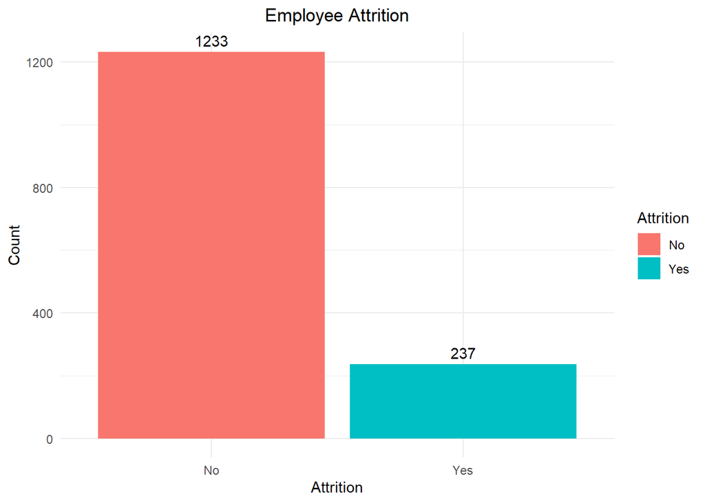

```r
# attrition count
data %>%
    group_by(Attrition) %>%
    tally() %>%
    ggplot(aes(x = Attrition, y = n,fill=Attrition)) +
    geom_bar(stat = "identity") +
    theme_minimal()+
    labs(x="Attrition", y="Count")+
    ggtitle("Employee Attrition")+
    geom_text(aes(label = n), vjust = -0.5, position = position_dodge(0.9))+
    theme(plot.title = element_text(hjust = 0.5))
```

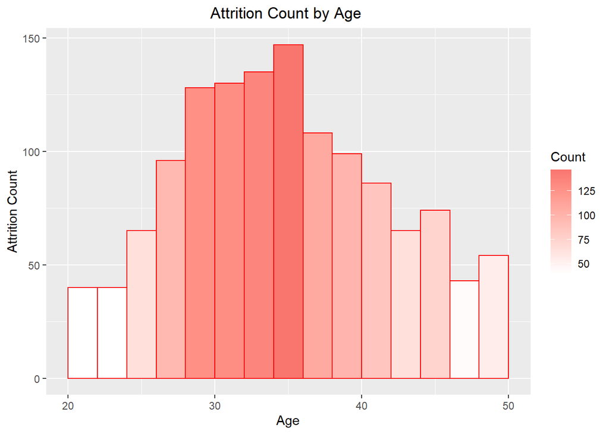

```r
# attrition count by age
ggplot(data=data, aes(Age)) +
  geom_histogram(breaks=seq(20, 50, by=2),
                 col="red",
                 aes(fill=..count..))+
  labs(x="Age", y="Attrition Count")+
  scale_fill_gradient("Count", low="white", high="#f9766e")+
  ggtitle("Attrition Count by Age ") +
  theme(plot.title = element_text(hjust = 0.5))
```

Here is another look at attrition by age. However, this time the proportion of attrition is the focus at each age. It is shown that the attrition in the 25-45 age range is not significantly higher when the total number of employees is considered.

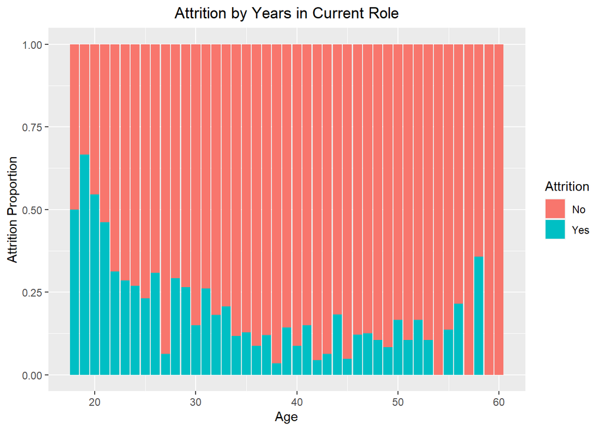

```r
# proportion of attrtion by age
ggplot(data, aes(x = Age)) + geom_bar(aes(fill = Attrition), position = 'fill') + labs(x = "Age", y = "Attrition Proportion") + ggtitle("Attrition by Years in Current Role") + theme(plot.title = element_text(hjust = 0.5))
```

The bar chart below shows that there is a weak trend in employees more likely to attrit earlier in their tenure in their current role.

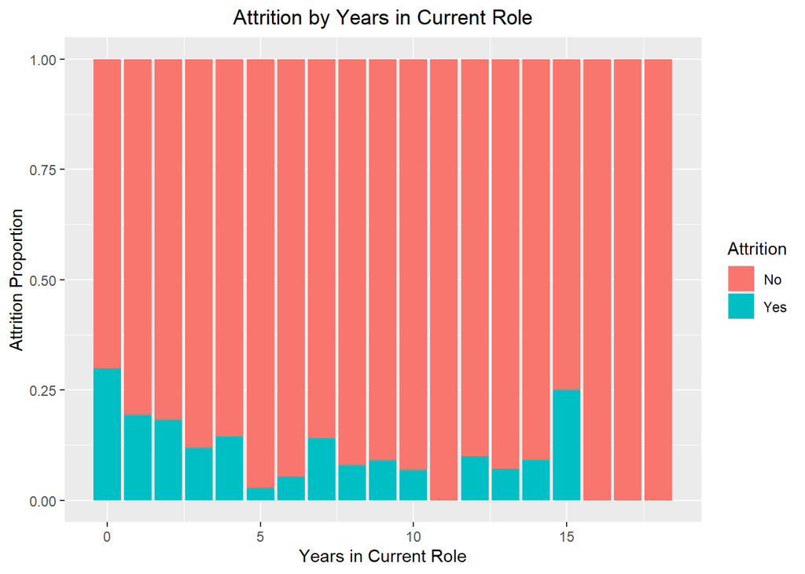

```r
# proportion of attrition by years in current role
ggplot(data, aes(x = YearsInCurrentRole)) + geom_bar(aes(fill = Attrition), position = 'fill') + labs(x = "Years in Current Role", y = "Attrition Proportion") + ggtitle("Attrition by Years in Current Role") + theme(plot.title = element_text(hjust = 0.5))
```

The Job Involvement bar chart is insightful in terms of attrition likelyhood. This was not surprising as you would expect those who are not involved in their job to explore other opportunities.

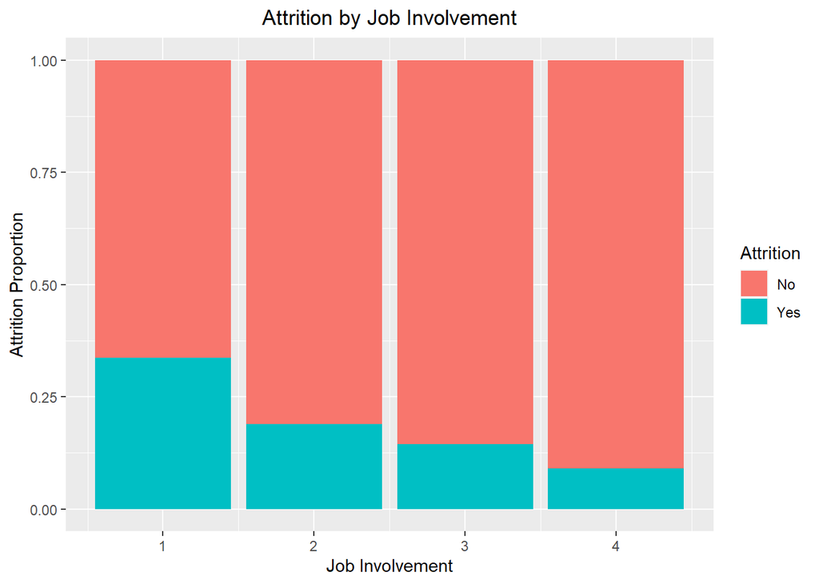

```r
# proportion of attrition by job involvement
ggplot(data, aes(x = JobInvolvement)) + geom_bar(aes(fill = Attrition), position = 'fill') + labs(x = "Job Involvement", y = "Attrition Proportion") + ggtitle("Attrition by Job Involvement") + theme(plot.title = element_text(hjust = 0.5))
```

No significant insight can be gained when looking at the relationship between salary hike and attrition. This can be surprising for those expecting a negative correlation between amount of salary increase and attrition.

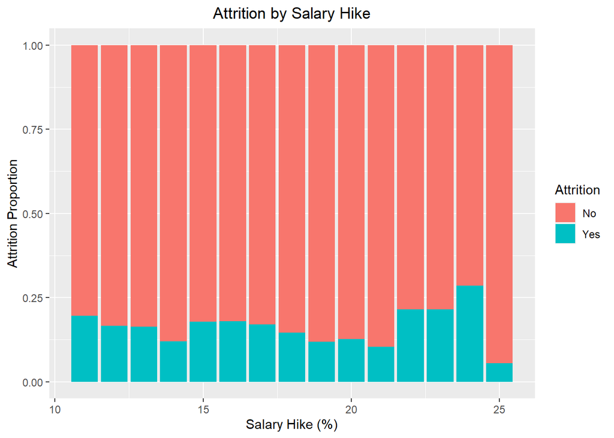

```r
# proportion of attrition by salary hike
ggplot(data, aes(x = PercentSalaryHike)) + geom_bar(aes(fill = Attrition), position = 'fill') + labs(x = "Salary Hike (%)", y = "Attrition Proportion") + ggtitle("Attrition by Salary Hike") + theme(plot.title = element_text(hjust = 0.5))
```

The more one travels for business, the more likely they are to attrit from this organization.

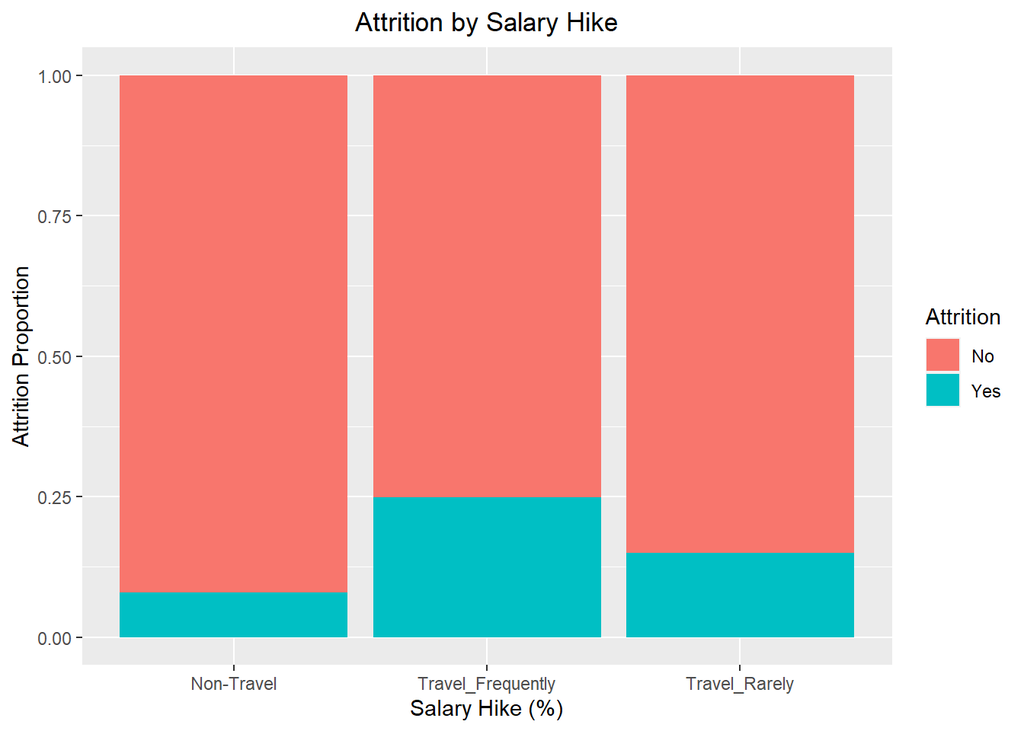

```r
# proportion of attrition by business travel
ggplot(data, aes(x = BusinessTravel)) + geom_bar(aes(fill = Attrition), position = 'fill') + labs(x = "Salary Hike (%)", y = "Attrition Proportion") + ggtitle("Attrition by Salary Hike") + theme(plot.title = element_text(hjust = 0.5))
```

Human Resources, Technical Degrees, and Marketing education backgrounds are the most at-risk groups of attriting.

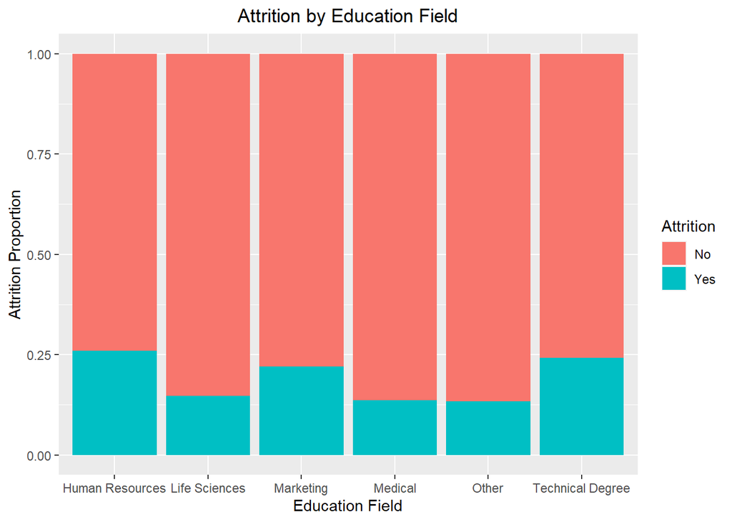

```r
# proportion of attrition by education field
ggplot(data, aes(x = EducationField)) + geom_bar(aes(fill = Attrition), position = 'fill') + labs(x = "Education Field", y = "Attrition Proportion") + ggtitle("Attrition by Education Field") + theme(plot.title = element_text(hjust = 0.5))
```

Sales Reps, Lab Techs, and Human Resources employees are the most at-risk groups of attriting.

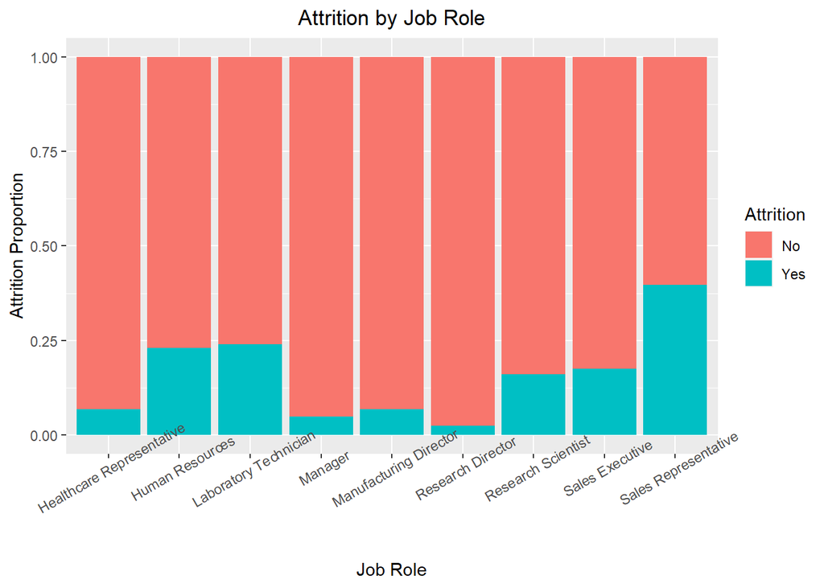

```r
# proportion of attrition by job role
ggplot(data, aes(x = JobRole)) + geom_bar(aes(fill = Attrition), position = 'fill') + labs(x = "Job Role", y = "Attrition Proportion") + ggtitle("Attrition by Job Role") + theme(plot.title = element_text(hjust = 0.5), axis.text.x = element_text(angle=30))
```

Single employees are significantly more likely to attrit than married or divorced employees.

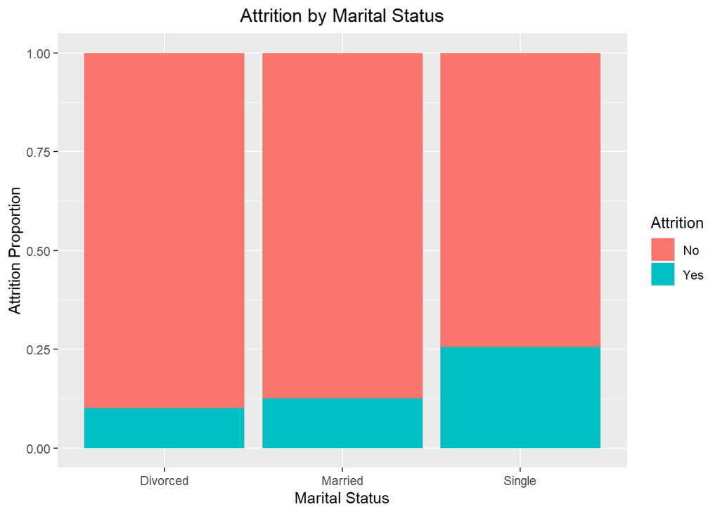

```r
# proportion of attrition by marital status
ggplot(data, aes(x = MaritalStatus)) + geom_bar(aes(fill = Attrition), position = 'fill') + labs(x = "Marital Status", y = "Attrition Proportion") + ggtitle("Attrition by Marital Status") + theme(plot.title = element_text(hjust = 0.5))
```

### Prediction Model

Split data into training and testing data

```r
set.seed(123)
sample <- sample.int(n = nrow(data), size =.5*nrow(data), replace=F)
train <- data[sample,]
test <- data[-sample,]
```

Build logistic regression model

```r
glm.fits <- glm(Attrition~.,data=train,family=binomial())
summary(glm.fits) #view model summary
```

```
##
## Call:
## glm(formula = Attrition ~ ., family = binomial(), data = train)
##
## Deviance Residuals:
##     Min       1Q   Median       3Q      Max
## -1.7658  -0.5060  -0.2735  -0.1116   3.1065
##
## Coefficients:
##                                    Estimate Std. Error z value Pr(>|z|)
## (Intercept)                      -1.103e+01  8.633e+02  -0.013 0.989810
## Age                              -5.783e-02  2.184e-02  -2.647 0.008109 **
## BusinessTravelTravel_Frequently   1.436e+00  5.988e-01   2.398 0.016490 *
## BusinessTravelTravel_Rarely       7.762e-01  5.580e-01   1.391 0.164213
## DailyRate                        -1.773e-04  3.205e-04  -0.553 0.580033
## DepartmentResearch & Development  1.383e+01  8.633e+02   0.016 0.987221
## DepartmentSales                   1.394e+01  8.633e+02   0.016 0.987114
## DistanceFromHome                  2.420e-02  1.533e-02   1.579 0.114405
## Education                         2.091e-01  1.292e-01   1.619 0.105522
## EducationFieldLife Sciences      -2.690e+00  1.399e+00  -1.923 0.054473 .
## EducationFieldMarketing          -2.085e+00  1.454e+00  -1.434 0.151570
## EducationFieldMedical            -2.690e+00  1.395e+00  -1.929 0.053755 .
## EducationFieldOther              -3.143e+00  1.506e+00  -2.087 0.036903 *
## EducationFieldTechnical Degree   -1.708e+00  1.426e+00  -1.198 0.230931
## EnvironmentSatisfaction          -4.002e-01  1.136e-01  -3.524 0.000425 ***
## GenderMale                       -6.699e-02  2.645e-01  -0.253 0.800074
## HourlyRate                       -1.407e-03  6.176e-03  -0.228 0.819745
## JobInvolvement                   -4.100e-01  1.716e-01  -2.389 0.016901 *
## JobLevel                         -2.143e-01  4.511e-01  -0.475 0.634826
## JobRoleHuman Resources            1.387e+01  8.633e+02   0.016 0.987184
## JobRoleLaboratory Technician      1.302e+00  6.538e-01   1.991 0.046469 *
## JobRoleManager                   -2.730e-01  1.372e+00  -0.199 0.842245
## JobRoleManufacturing Director     7.545e-01  6.602e-01   1.143 0.253132
## JobRoleResearch Director         -1.430e+00  1.429e+00  -1.000 0.317156
## JobRoleResearch Scientist        -9.178e-03  6.848e-01  -0.013 0.989306
## JobRoleSales Executive            6.426e-01  1.648e+00   0.390 0.696499
## JobRoleSales Representative       1.931e+00  1.712e+00   1.128 0.259387
## JobSatisfaction                  -3.154e-01  1.159e-01  -2.722 0.006494 **
## MaritalStatusMarried              6.082e-01  3.871e-01   1.571 0.116155
## MaritalStatusSingle               1.104e+00  5.087e-01   2.169 0.030079 *
```

[output cut: 10 more lines]

```
## WorkLifeBalance                  -2.593e-01  1.665e-01  -1.558 0.119287
## YearsAtCompany                    1.249e-01  4.955e-02   2.521 0.011699 *
## YearsInCurrentRole               -1.840e-01  6.091e-02  -3.021 0.002522 **
## YearsSinceLastPromotion           9.042e-02  5.643e-02   1.602 0.109089
## YearsWithCurrManager             -1.157e-01  6.570e-02  -1.761 0.078292 .
## ---
## Signif. codes:  0 '***' 0.001 '**' 0.01 '*' 0.05 '.' 0.1 ' ' 1
##
## (Dispersion parameter for binomial family taken to be 1)
##
##     Null deviance: 647.64  on 734  degrees of freedom
## Residual deviance: 445.66  on 690  degrees of freedom
## AIC: 535.66
##
## Number of Fisher Scoring iterations: 15
```

```r
coef(glm.fits) #view coefficients
```

```
##                      (Intercept)                              Age
##                    -1.102653e+01                    -5.782846e-02
##  BusinessTravelTravel_Frequently      BusinessTravelTravel_Rarely
##                     1.435827e+00                     7.761672e-01
##                        DailyRate DepartmentResearch & Development
##                    -1.773263e-04                     1.382723e+01
##                  DepartmentSales                 DistanceFromHome
##                     1.394331e+01                     2.420443e-02
##                        Education      EducationFieldLife Sciences
##                     2.091004e-01                    -2.690277e+00
##          EducationFieldMarketing            EducationFieldMedical
##                    -2.084628e+00                    -2.690086e+00
##              EducationFieldOther   EducationFieldTechnical Degree
##                    -3.142755e+00                    -1.707870e+00
##          EnvironmentSatisfaction                       GenderMale
##                    -4.002301e-01                    -6.698613e-02
##                       HourlyRate                   JobInvolvement
##                    -1.407322e-03                    -4.100387e-01
##                         JobLevel           JobRoleHuman Resources
##                    -2.142588e-01                     1.386791e+01
##     JobRoleLaboratory Technician                   JobRoleManager
##                     1.301758e+00                    -2.729842e-01
##    JobRoleManufacturing Director         JobRoleResearch Director
##                     7.544596e-01                    -1.429548e+00
##        JobRoleResearch Scientist           JobRoleSales Executive
##                    -9.178389e-03                     6.426355e-01
##      JobRoleSales Representative                  JobSatisfaction
##                     1.931330e+00                    -3.154296e-01
##             MaritalStatusMarried              MaritalStatusSingle
##                     6.081746e-01                     1.103502e+00
##                    MonthlyIncome                      MonthlyRate
##                    -7.156042e-06                    -1.397516e-05
##               NumCompaniesWorked                      OverTimeYes
##                     1.170651e-01                     1.590136e+00
##                PercentSalaryHike                PerformanceRating
##                    -8.071387e-02                     9.853258e-01
##         RelationshipSatisfaction                 StockOptionLevel
##                    -1.550453e-01                    -8.643591e-02
##                TotalWorkingYears            TrainingTimesLastYear
##                    -7.190392e-03                    -2.017144e-01
##                  WorkLifeBalance                   YearsAtCompany
##                    -2.593222e-01                     1.249110e-01
##               YearsInCurrentRole          YearsSinceLastPromotion
##                    -1.839957e-01                     9.041757e-02
##             YearsWithCurrManager
##                    -1.156825e-01
```

```r
glm.probs <- predict(glm.fits, type="response") #store predictions to variable
glm.probs[0:10] # explore first 10 predictions on training data
```

```
##         415         463         179         526         195         938
## 0.864106958 0.024016391 0.102622303 0.408159088 0.031797745 0.257951206
##        1142        1323        1253        1268
## 0.160287122 0.001473934 0.069905085 0.006127139
```

Create confusion matrix to obtain model training accuracy and training error rate

```r
contrasts(data$Attrition) #validate that the dummy variable for Attrition indicates that 0 = No and 1 = Yes.
```

```
##     Yes
## No    0
## Yes   1
```

```r
#create a vector of class predictions
glm.pred=rep("No", 735)
glm.pred[glm.probs>.5]="Yes"

#create a confusion matrix
cm <- table(glm.pred, train$Attrition)

#check training accuracy
(602+51)/735
```

```
## [1] 0.8884354
```

```r
mean(glm.pred==train$Attrition)
```

```
## [1] 0.8884354
```

```r
# calculate the training error rate
1-((602+51)/735)
```

```
## [1] 0.1115646
```

Use the model to predict on the test data

```r
## predict on the test data
glm.probs <- predict(glm.fits,test,type="response")

#create a vector of class predictions
glm.pred=rep("No", 735)
glm.pred[glm.probs>.5]="Yes"

#create a confusion matrix
cm <- table(glm.pred, test$Attrition)

mean(glm.pred == test$Attrition)
```

```
## [1] 0.8721088
```

Create a function to obtain model metrics

```r
#create a function to obtain model metrics
metrics <- function(confusionmatrix) {

  n = sum(confusionmatrix) # number of instances
  nc = nrow(confusionmatrix) #number of classes
  diag = diag(confusionmatrix) # number of correctly classified instances per class
  rowsums = apply(confusionmatrix,1,sum) # number of instances per class
  colsums = apply(confusionmatrix,2,sum) # number of predictions per class
  p = rowsums / n # distribution of instances of the actual classes
  q = colsums / n # distribution of instances of the predicted classes
  accuracy= sum(diag)/n # how accurate is the model
  precision= diag / colsums # how accurate is the model when prediction is "Yes" Attrition
  recall= diag/rowsums # what percentage of "Yes" attritions did model recognize
  f1= 2 * precision * recall / (precision+recall)

  list(
    accuracy,
    precision,
    recall,
    f1
  )
}
```

Run the confusion matrix through the function to obtain the metrics

```r
# run the confusion matrix for the glm model through the metrics function amd calculate the test error rate and other metrics
c(glm_accuracy,glm_precision,glm_recall,glm_f1) %<-% metrics(cm)
```

```r
step.model <- glm.fits %>% stepAIC(trace=FALSE)
summary(step.model)
```

```
##
## Call:
## glm(formula = Attrition ~ Age + BusinessTravel + DistanceFromHome +
##     Education + EducationField + EnvironmentSatisfaction + JobInvolvement +
##     JobRole + JobSatisfaction + MaritalStatus + NumCompaniesWorked +
##     OverTime + PercentSalaryHike + PerformanceRating + TrainingTimesLastYear +
##     WorkLifeBalance + YearsAtCompany + YearsInCurrentRole + YearsSinceLastPromotion +
##     YearsWithCurrManager, family = binomial(), data = train)
##
## Deviance Residuals:
##     Min       1Q   Median       3Q      Max
## -1.8388  -0.5164  -0.2896  -0.1166   3.1760
##
## Coefficients:
##                                 Estimate Std. Error z value Pr(>|z|)
## (Intercept)                      1.18785    2.04116   0.582 0.560603
## Age                             -0.06633    0.01769  -3.750 0.000177 ***
## BusinessTravelTravel_Frequently  1.38210    0.57817   2.390 0.016827 *
## BusinessTravelTravel_Rarely      0.77510    0.53843   1.440 0.149994
## DistanceFromHome                 0.02513    0.01512   1.662 0.096501 .
## Education                        0.21670    0.12699   1.706 0.087916 .
## EducationFieldLife Sciences     -2.30088    1.16302  -1.978 0.047887 *
## EducationFieldMarketing         -1.70466    1.22621  -1.390 0.164474
## EducationFieldMedical           -2.32864    1.16148  -2.005 0.044975 *
## EducationFieldOther             -2.83499    1.28753  -2.202 0.027674 *
## EducationFieldTechnical Degree  -1.31082    1.19901  -1.093 0.274282
## EnvironmentSatisfaction         -0.40148    0.11205  -3.583 0.000339 ***
## JobInvolvement                  -0.43296    0.16721  -2.589 0.009616 **
## JobRoleHuman Resources           0.51136    1.06232   0.481 0.630258
## JobRoleLaboratory Technician     1.57256    0.58898   2.670 0.007586 **
## JobRoleManager                  -0.72647    0.94126  -0.772 0.440230
## JobRoleManufacturing Director    0.79900    0.65025   1.229 0.219158
## JobRoleResearch Director        -1.76061    1.32636  -1.327 0.184377
## JobRoleResearch Scientist        0.31333    0.61089   0.513 0.608019
## JobRoleSales Executive           0.81889    0.61354   1.335 0.181972
## JobRoleSales Representative      2.35779    0.66945   3.522 0.000428 ***
## JobSatisfaction                 -0.31883    0.11314  -2.818 0.004831 **
## MaritalStatusMarried             0.61860    0.36027   1.717 0.085972 .
## MaritalStatusSingle              1.17460    0.37557   3.128 0.001763 **
## NumCompaniesWorked               0.10994    0.05071   2.168 0.030160 *
## OverTimeYes                      1.52070    0.25785   5.898 3.69e-09 ***
## PercentSalaryHike               -0.08937    0.05667  -1.577 0.114815
## PerformanceRating                1.04010    0.54796   1.898 0.057681 .
## TrainingTimesLastYear           -0.19179    0.09851  -1.947 0.051551 .
## WorkLifeBalance                 -0.26363    0.16553  -1.593 0.111235
## YearsAtCompany                   0.11024    0.04444   2.481 0.013108 *
## YearsInCurrentRole              -0.18271    0.05909  -3.092 0.001988 **
## YearsSinceLastPromotion          0.08588    0.05500   1.561 0.118454
## YearsWithCurrManager            -0.10768    0.06495  -1.658 0.097350 .
## ---
## Signif. codes:  0 '***' 0.001 '**' 0.01 '*' 0.05 '.' 0.1 ' ' 1
##
## (Dispersion parameter for binomial family taken to be 1)
##
##     Null deviance: 647.64  on 734  degrees of freedom
## Residual deviance: 450.38  on 701  degrees of freedom
## AIC: 518.38
##
## Number of Fisher Scoring iterations: 7
```

```r
step.probs <- predict(step.model,test,type="response")
step.pred=rep("No", 735)
step.pred[step.probs>.5]="Yes"
step_cm <- table(step.pred, test$Attrition)

c(step_accuracy,step_precision,step_recall,step_f1) %<-% metrics(step_cm)
```

Recreate the logistic regression model using the reduced predictors method and explore the metrics. The predictors used here are based on what was deemed significant by the original logistic regression method above.

```r
## recreate the model using reduced predictors
Attritions = data
Attritions$TravelFrequently = 0
Attritions$TravelFrequently[Attritions$BusinessTravel=="Travel_Frequently"]=1
Attritions$LifeSciences=0
Attritions$LifeSciences[Attritions$EducationField== "Life Sciences"]=1
Attritions$Medical=0
Attritions$Medical[Attritions$EducationField==  "Medical"]=1
Attritions$Other=0
Attritions$Other[Attritions$EducationField==    "Other"]=1
Attritions$LaboratoryTechnician=0
Attritions$LaboratoryTechnician[Attritions$JobRole == "Laboratory Technician"]=1
Attritions$Single=0
Attritions$Single[Attritions$MaritalStatus==    "Single"]=1
Attritions$OvertimeYes=0
Attritions$OvertimeYes[Attritions$OverTime==    "Yes"]=1

set.seed(13)
sample <- sample.int(n = nrow(Attritions), size =.5*nrow(Attritions), replace=F)
Attritions_train <- Attritions[sample,]
Attritions_test <- Attritions[-sample,]

reduced = glm(Attrition ~ TravelFrequently + LifeSciences+ Medical+ Other+ LaboratoryTechnician+ Single+ OvertimeYes+ Age+ EnvironmentSatisfaction+ JobInvolvement+ JobSatisfaction+ NumCompaniesWorked+ PerformanceRating+ TrainingTimesLastYear+ YearsAtCompany+ YearsInCurrentRole+ YearsWithCurrManager, family=binomial, data=Attritions_train)
summary(reduced)
```

```
##
## Call:
## glm(formula = Attrition ~ TravelFrequently + LifeSciences + Medical +
##     Other + LaboratoryTechnician + Single + OvertimeYes + Age +
##     EnvironmentSatisfaction + JobInvolvement + JobSatisfaction +
##     NumCompaniesWorked + PerformanceRating + TrainingTimesLastYear +
##     YearsAtCompany + YearsInCurrentRole + YearsWithCurrManager,
##     family = binomial, data = Attritions_train)
##
## Deviance Residuals:
##     Min       1Q   Median       3Q      Max
## -1.6974  -0.4975  -0.3070  -0.1527   3.0860
##
## Coefficients:
##                         Estimate Std. Error z value Pr(>|z|)
## (Intercept)              4.04337    1.46736   2.756 0.005859 **
## TravelFrequently         0.37910    0.33574   1.129 0.258829
## LifeSciences            -1.01271    0.32614  -3.105 0.001902 **
## Medical                 -1.07639    0.34000  -3.166 0.001546 **
## Other                   -1.10402    0.56097  -1.968 0.049064 *
## LaboratoryTechnician     0.51299    0.32196   1.593 0.111078
## Single                   0.86381    0.25707   3.360 0.000779 ***
## OvertimeYes              1.82142    0.26533   6.865 6.66e-12 ***
## Age                     -0.06218    0.01675  -3.712 0.000205 ***
## EnvironmentSatisfaction -0.41616    0.11994  -3.470 0.000521 ***
## JobInvolvement          -0.47782    0.16985  -2.813 0.004905 **
## JobSatisfaction         -0.39777    0.12010  -3.312 0.000926 ***
## NumCompaniesWorked       0.14297    0.05359   2.668 0.007631 **
## PerformanceRating       -0.04225    0.34313  -0.123 0.901996
## TrainingTimesLastYear   -0.26356    0.10825  -2.435 0.014906 *
## YearsAtCompany           0.13456    0.04552   2.956 0.003113 **
## YearsInCurrentRole      -0.17503    0.06198  -2.824 0.004746 **
## YearsWithCurrManager    -0.15862    0.06957  -2.280 0.022602 *
## ---
## Signif. codes:  0 '***' 0.001 '**' 0.01 '*' 0.05 '.' 0.1 ' ' 1
##
## (Dispersion parameter for binomial family taken to be 1)
##
##     Null deviance: 569.70  on 734  degrees of freedom
## Residual deviance: 431.49  on 717  degrees of freedom
## AIC: 467.49
##
## Number of Fisher Scoring iterations: 6
```

```r
reduced.probs <- predict(reduced, Attritions_test,type="response")
reduced.pred=rep("No", 735)
reduced.pred[reduced.probs>.5]="Yes"
red_cm <- table(reduced.pred, Attritions_test$Attrition)

c(red_accuracy,red_precision,red_recall,red_f1) %<-% metrics(red_cm)
```

The AIC (Akaike Information Criteron) is a metric that is used to evaluate the possiblity of overfitting. The smallest AIC may help avoid over-fitting. The reduced model has the best chance of avoiding over-fitting.

```r
#compare the aic of the models
glm.fits$aic
```

```
## [1] 535.6645
```

```r
step.model$aic
```

```
## [1] 518.3762
```

```r
reduced$aic
```

```
## [1] 467.4939
```

```r
# fit a classification tree in order to predict attrition
tree.attrition = tree(Attrition~.,train)
summary(tree.attrition)
```

```
##
## Classification tree:
## tree(formula = Attrition ~ ., data = train)
## Variables actually used in tree construction:
##  [1] "MonthlyIncome"            "MaritalStatus"
##  [3] "OverTime"                 "YearsWithCurrManager"
##  [5] "PercentSalaryHike"        "DailyRate"
##  [7] "MonthlyRate"              "EnvironmentSatisfaction"
##  [9] "JobRole"                  "DistanceFromHome"
## [11] "EducationField"           "NumCompaniesWorked"
## [13] "JobLevel"                 "RelationshipSatisfaction"
## [15] "StockOptionLevel"         "Education"
## Number of terminal nodes:  25
## Residual mean deviance:  0.4933 = 350.2 / 710
## Misclassification error rate: 0.09116 = 67 / 735
```

```r
#estimate the test error
tree.pred=predict(tree.attrition, test, type="class")
tree_cm<- table(tree.pred,test$Attrition)

#obtain test metrics
c(tree_accuracy,tree_precision,tree_recall,tree_f1) %<-% metrics(tree_cm)
```

Fit a pruned tree and obtain test metrics

```r
set.seed(24)
cv.attrition <- cv.tree(tree.attrition,FUN=prune.misclass)
names(cv.attrition)
```

```
## [1] "size"   "dev"    "k"      "method"
```

```r
cv.attrition
```

```
## $size
## [1] 25 19 14 13  6  5  3  1
##
## $dev
## [1] 130 129 114 115 115 118 119 121
##
## $k
## [1]     -Inf 0.000000 1.800000 2.000000 2.714286 3.000000 3.500000 5.500000
##
## $method
## [1] "misclass"
##
## attr(,"class")
## [1] "prune"         "tree.sequence"
```

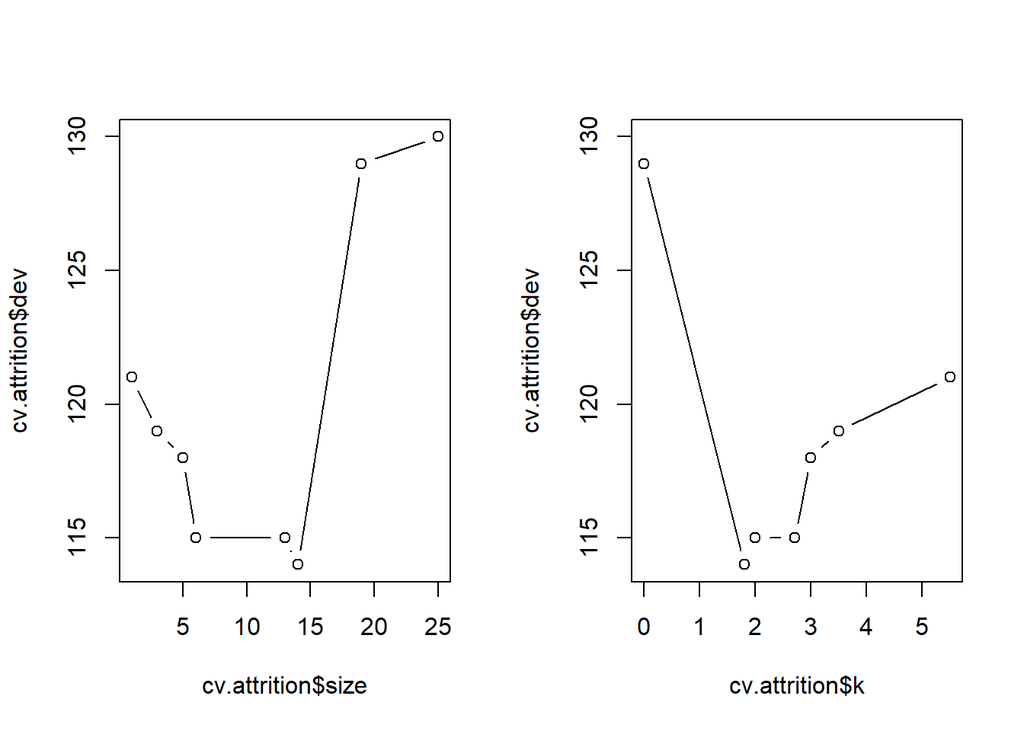

```r
#plot the error rate as a function of both size and k
par(mfrow=c(1,2))
plot(cv.attrition$size,cv.attrition$dev,type='b')
plot(cv.attrition$k,cv.attrition$dev,type='b')
```

The visualization shows the where the ideal number of trees which is then input in the final pruned tree model

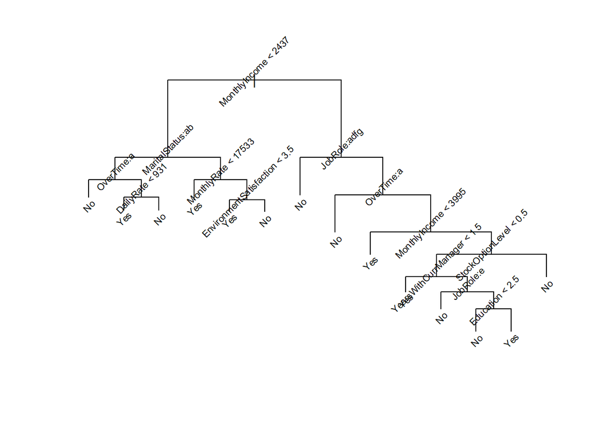

```r
#prune the tree to obtain the 14-node tree (14 is chosen since the plot shows it has the lowest dev which represents the test error)
prune.tree=prune.misclass(tree.attrition,best=14)
plot(prune.tree)
text(prune.tree,srt=45,cex=0.66)
```

```r
#check performance of pruned tree on test set
tree.pred = predict(prune.tree, test, type="class")
prune_cm <- table(tree.pred, test$Attrition)

#obtain test metrics
c(prune_accuracy,prune_precision,prune_recall,prune_f1) %<-% metrics(prune_cm)
```

Fit a bagged random forest model and obtain test metrics

```r
## fit a bagged RF model
bag.attrition = randomForest(Attrition~.,data=train,mtry=31,importance=TRUE)
bag.pred = predict(bag.attrition,newdata=test)
bag_cm <- table(bag.pred,test$Attrition)

#obtain test metrics
c(bag_accuracy,bag_precision,bag_recall,bag_f1) %<-% metrics(bag_cm)
```

Change the number of trees grown and obtain test metrics

```r
#change the number of trees grown
rf.attrition = randomForest(Attrition~.,data=train,mtry=31,ntree=25)
rf.pred = predict(rf.attrition,newdata=test)
changed_cm <- table(rf.pred,test$Attrition)

#obtain test metrics
c(changed_accuracy,changed_precision,changed_recall,changed_f1) %<-% metrics(changed_cm)
```

Now that test metrics have been obtained for all the Logistic Regression models and the Tree models a final comparision can be done to choose the best model.

```r
# create a dataframe to compare the metrics easier
model <- c('Logistic Regression','Stepwise Logistic Regression','Reduced Logistic Regression','Decision Tree', 'Pruned Decision Tree', 'Bagged Random Forest', 'Changed Random Forest')
accuracy <- c(glm_accuracy, step_accuracy, red_accuracy, tree_accuracy, prune_accuracy, bag_accuracy, changed_accuracy)
precision <- c(glm_precision[2], step_precision[2], red_precision[2], tree_precision[2], prune_precision[2], bag_precision[2], changed_precision[2])
recall <- c(glm_recall[2], step_recall[2], red_recall[2], tree_recall[2], prune_recall[2], bag_recall[2], changed_recall[2])
f1 <- c(glm_f1[2], step_f1[2], red_f1[2], tree_f1[2], prune_f1[2], bag_f1[2], changed_f1[2])
metrics_df <- data.frame(model, accuracy, precision,recall,f1)
```

Accuracy measures the overall percentage of correct predictions for both Yes and No when predicting attrition. The most accurate model is the stepwise logistic regression model.

```r
#sort the dataframe by accuracy
arrange(metrics_df,desc(accuracy))
```

```
##                          model  accuracy precision    recall        f1
## 1 Stepwise Logistic Regression 0.8761905 0.3865546 0.7187500 0.5027322
## 2          Logistic Regression 0.8721088 0.3949580 0.6811594 0.5000000
## 3        Changed Random Forest 0.8707483 0.3025210 0.7500000 0.4311377
## 4         Bagged Random Forest 0.8598639 0.2100840 0.7352941 0.3267974
## 5  Reduced Logistic Regression 0.8448980 0.2907801 0.7454545 0.4183673
## 6                Decision Tree 0.8244898 0.3613445 0.4479167 0.4000000
## 7         Pruned Decision Tree 0.8217687 0.3361345 0.4347826 0.3791469
```

Precision measures how often the model is correct when predicting ‘Yes’ for attrition. While these precision scores may seem low, it should be noted that high precision is difficult to obtain in unbalanced class sizes. In this case, the imbalance is very clear as 16% of the employees in the dataset attritted, while the other 84% remain employed. The model w/ the best precision score is the logistic regression model followed by the stepwise model.

```r
#sort the dataframe by precision
arrange(metrics_df,desc(precision))
```

```
##                          model  accuracy precision    recall        f1
## 1          Logistic Regression 0.8721088 0.3949580 0.6811594 0.5000000
## 2 Stepwise Logistic Regression 0.8761905 0.3865546 0.7187500 0.5027322
## 3                Decision Tree 0.8244898 0.3613445 0.4479167 0.4000000
## 4         Pruned Decision Tree 0.8217687 0.3361345 0.4347826 0.3791469
## 5        Changed Random Forest 0.8707483 0.3025210 0.7500000 0.4311377
## 6  Reduced Logistic Regression 0.8448980 0.2907801 0.7454545 0.4183673
## 7         Bagged Random Forest 0.8598639 0.2100840 0.7352941 0.3267974
```

```r
# sort the dataframe by recall
arrange(metrics_df,desc(recall))
```

```
##                          model  accuracy precision    recall        f1
## 1        Changed Random Forest 0.8707483 0.3025210 0.7500000 0.4311377
## 2  Reduced Logistic Regression 0.8448980 0.2907801 0.7454545 0.4183673
## 3         Bagged Random Forest 0.8598639 0.2100840 0.7352941 0.3267974
## 4 Stepwise Logistic Regression 0.8761905 0.3865546 0.7187500 0.5027322
## 5          Logistic Regression 0.8721088 0.3949580 0.6811594 0.5000000
## 6                Decision Tree 0.8244898 0.3613445 0.4479167 0.4000000
## 7         Pruned Decision Tree 0.8217687 0.3361345 0.4347826 0.3791469
```

The f1 score is a mean of the recall and precision scores. f1 score is considered the best metric as it takes into consideration a portion of the other metrics. The stepwise model has the best f1 score.

```r
# sort the dataframe by f1 score
arrange(metrics_df,desc(f1))
```

```
##                          model  accuracy precision    recall        f1
## 1 Stepwise Logistic Regression 0.8761905 0.3865546 0.7187500 0.5027322
## 2          Logistic Regression 0.8721088 0.3949580 0.6811594 0.5000000
## 3        Changed Random Forest 0.8707483 0.3025210 0.7500000 0.4311377
## 4  Reduced Logistic Regression 0.8448980 0.2907801 0.7454545 0.4183673
## 5                Decision Tree 0.8244898 0.3613445 0.4479167 0.4000000
## 6         Pruned Decision Tree 0.8217687 0.3361345 0.4347826 0.3791469
## 7         Bagged Random Forest 0.8598639 0.2100840 0.7352941 0.3267974
```

```r
bestmodel <- step.model
```

### Tutorial on Shiny Web Interface

Please note that the code below is for reference. There is a separate file, shiny.R, that will need to be run to use the web interface of the prediction model.

The tutorial will consist of detailed commented code to explain all the functions used to create the Shiny product.

Below is the code to set up the ui (user interface) of the Shiny model. The ui is one of two requirements for Shiny to execute, the other requirement is server, for which additional detail is provided further down. Since the code on this page is for show and will not be executed, I will be providing additional context behind how the ui and server requirements are built in smaller (non-executing) code chunks.

```r
ui <- fluidPage( # this function is used to create a display that automatically adjusts to the dimensions of the user's browser window. For this app, the fluidPage will consist of a fluidRow to hold the title and a mainPanel to contain the two tabs of the app.
  fluidRow( # used to build the layout up from a grid system. The purpose of the fluidRow here is to store a fluid titlePanel
    titlePanel( #this function holds the title of the App
      h1("Employee Attrition Predictor", align="center")
    )
  ),
  hr(), #hr, or horizontal rule. For this app, hr() is used to provide separation
  theme = shinytheme("superhero"), # preset theme of the application, this function is a quick way to provide a preset design/template to the app
  mainPanel( #designated main area of the app. For this app, it will store the the two tabs.

    tabsetPanel( # creats a tabset to help divide the ouput into multiple independently viewable sections. This is used in this app to separate the individual/manual input of predictors in the first tab from the second tab which allows an easier input through  uploading a csv
                type="tabs",
                tabPanel("Single Prediction", #creates a tab panel; here it is being used to store the first of the two tabs - the Single Prediction
                         hr(),
                         textOutput("Pred"), #renders a reactive output variable as text. Here it will render "Pred" from the server function,(below) which is the prediction of probability of attrition.
                         hr(),
                         fluidRow(
                           column(3, # this function creates columns to the store the data within it. The"3" represents the column width (max is 12).
                                  h4("Input/Select Predictors"),
                                  numericInput(inputId = 'Age', label = 'Age', value = 18, min = 18, max = 99, step = NA, width = NULL), # creates an input control for entry of numeric values; in this situation it allows the app user to input the age predictor, the "value" chooses the default/initial value to be shown. inputId is the slot that will be used to access the value. Below in the server function, the inputId is used to connect the input to the reactive dataframe.
                                  selectInput(inputId = 'BusinessTravel', label = 'Business Travel', c("Travel_Rarely", "Travel_Frequently", "Non-Travel"), selected = "Non-Travel"), #creates a select list that can be used to choose a single or multiple items from a list of values. In this case, it allows for a single value (Business Travel) to be selected and used as a predictor.
                                  numericInput(inputId = 'DistanceFromHome', label = 'Distance From Home', value = 7, min = 0, max = 330, step = NA, width = NULL),
                                  numericInput(inputId = 'Education', label = 'Education Level', value = 0, min = 0, max = 5, step = NA, width = NULL),
                                  selectInput(inputId = 'EducationField', label = 'Education Field', c("Human Resources", "Life Sciences", "Marketing", "Medical", "Other", "Technical Degree"), selected = "Medical")

                           ),
                           column(3, br(), br(), br(),
                                  numericInput(inputId = 'EnvironmentSatisfaction', label = 'Environment Satsifaction', value = 3, min = 1, max = 4, step = NA, width = NULL),
                                  numericInput(inputId = 'JobInvolvement', label = 'Job Involvement', value = 3, min = 1, max = 4, step = NA, width = NULL),
                                  selectInput(inputId = "JobRole", label = "Job Role", c("Healthcare Representative", "Human Resources", "Labratory Technician", "Manager", "Manufacturing Director", "Research Director", "Research Scientist", "Sales Executive", "Sales Representative"), selected = "Manager"),
                                  numericInput(inputId = "JobSatisfaction", label = "Job Satisfaction", value = 3, min = 1, max =4, step = NA, width = NULL),
                                  selectInput(inputId = "MaritalStatus", label = "Marital Status", c("Divorced", "Married", "Single"), selected = "Married"),

                           ),
                           column(3, br(), br(), br(),
                                  numericInput(inputId = "NumCompaniesWorked", label = "Number of Companies Worked", value = 2, min = 0, max = 20, step = NA, width = NULL),
                                  selectInput(inputId = "OverTime", label = "Overtime", c("No", "Yes"), selected = "No"),
                                  numericInput(inputId = "PercentSalaryHike", label = "Salary Hike (%)", value = 14, min = 0, max = 100, step = NA, width = NULL),
                                  numericInput(inputId = "PerformanceRating", label = "Performance Rating", value = 3, min = 1, max = 5, step = NA, width = NULL),
                                  numericInput(inputId = "TrainingTimesLastYear", label = "Number of Trainings Attended Last Year", value = 3, min = 0, max = 50, step = NA, width = NULL)
                           ),
                           column(3, br(), br(), br(),
                                  numericInput(inputId = "WorkLifeBalance", label = "Work Life Balance Satisfaction", value = 3, min = 1, max = 4, step = NA, width = NULL),
                                  numericInput(inputId = "YearsAtCompany", label = "Number of Years at Company", value = 15, min = 0, max = 99, step = NA, width = NULL),
                                  numericInput(inputId = "YearsInCurrentRole", label = "Number of Years in Current Role", value = 3, min = 0, max = 50, step = NA, width = NULL),
                                  numericInput(inputId = "YearsSinceLastPromotion", label = "Number of Years Since Last Promotion", value = 10, min = 0, max = 30, step = NA, width = NULL),
                                  numericInput(inputId = "YearsWithCurrManager", label = "Number of Years With Current Manager", value = 3, min = 0, max = 20, step = NA, width = NULL)
                           )

                         ),
                         hr(),

                         fluidRow(h5("The prediction model above was built using the IBM HR Analytics Employee Attrition and Performance dataset. The dataset was created by IBM data scientists to help uncover the factors that lead to employee attrition and allow exploratory data analysis for an organization."))

                         ),
                tabPanel("Predict from csv", # this tab allows the user to input a csv and obtain an output of the csv in a table format with an added column containing the prediction probability of attrition
                         h5("Uploading a csv containing employee data. The data will render a table with a new column added at the end with the probability of attrition."),
                         hr(),
                         fileInput("csvFile", "Upload csv"), #creates a file upload control that can be used to upload one or more files
                         tableOutput("Prediction"), #renders a table within the application page; here this function calls the "Prediction" from the reactive function in the Server code below


                )
    )

                )



      )
```

```r
server = function (input, output) {
  df <- reactive({ #wraps a normal expression to create a reactive expression. The reactive expression in this case is the data.frame which will update a create a dataframe based on the user inputs below. These inputs are directly from the UI. This df will be used to make predictions as shown below.
    data.frame(Age=input$Age,

               BusinessTravel=input$BusinessTravel,

               DistanceFromHome=input$DistanceFromHome,

               Education=input$Education,

               EducationField=input$EducationField,

               EnvironmentSatisfaction=input$EnvironmentSatisfaction,

               JobInvolvement=input$JobInvolvement,

               JobRole=input$JobRole,

               JobSatisfaction=input$JobSatisfaction,

               MaritalStatus=input$MaritalStatus,

               NumCompaniesWorked=input$NumCompaniesWorked,

               OverTime=input$OverTime,

               PercentSalaryHike=input$PercentSalaryHike,

               PerformanceRating=input$PerformanceRating,

               TrainingTimesLastYear=input$TrainingTimesLastYear,

               WorkLifeBalance=input$WorkLifeBalance,

               YearsAtCompany=input$YearsAtCompany,

               YearsInCurrentRole=input$YearsInCurrentRole,

               YearsSinceLastPromotion=input$YearsSinceLastPromotion,

               YearsWithCurrManager=input$YearsWithCurrManager



    )
  })

  pred <- reactive({
    predict(bestmodel,df(), type="response") # the prediction occurs here on the reactive dataframe created by user inputs
  })

  output$Pred <- renderText({paste("The probability of attrition is",round(pred(), digits=2),".")}) # the renderText function makes a reactive version of the given function in a single-element charactor vector. The text being rendered is the prediction made in the line of code above.

  rawData <- eventReactive(input$csvFile, { #eventReactive responds to "event-like" reactive inputs (in this case, the csv file containing the data for predictions)
    read.csv(input$csvFile$datapath)
  })


  })

  prediction <- reactive({
    predict(bestmodel,rawData(),type="response")
  })

  output$Prediction <- renderTable({cbind(rawData(), prediction())})



}
```

```r
shinyApp(ui=ui,server=server) # creates the Shiny app objects
```